# Practical: exploring outbreak data using the tidyverse

# Introduction

## On the tidyverse

The [tidyverse](https://www.tidyverse.org/) is a collection of **R** packages designed for data science. Developed with high standards of coding practices and software development, these packages form a consistent ecosystem to handle and visualise data. In this practical, we will mostly rely on the following packages:

- [*dplyr*](https://dplyr.tidyverse.org/) for handling data, making new variables, building summaries, number-crunching
- [*tidyr*](https://tidyr.tidyverse.org/) to re-arrange tidy/data
- [*ggplot2*](https://ggplot2.tidyverse.org/) to visualise data
- [*forcats*](https://forcats.tidyverse.org/) to handle categorical data (`factors`)
- [*magrittr*](https://magrittr.tidyverse.org/) for the piping operator (`%>%`)

Most of these functionalities are summarised in handy cheatsheets. We provide links to the most relevant ones below:

- [basics of R](http://github.com/rstudio/cheatsheets/raw/master/base-r.pdf) (not tidyverse, but they remain very useful)
- [data transformation using *dplyr*](https://github.com/rstudio/cheatsheets/raw/master/data-transformation.pdf)
- [data visualisation using *ggplot2*](https://github.com/rstudio/cheatsheets/raw/master/data-visualization-2.1.pdf)
- [handling factors using *forcats*](https://github.com/rstudio/cheatsheets/raw/master/factors.pdf)

## Exploring outbreak data

### What we will do today

This practical will use different outbreak data to illustrate how the various packages mentioned above can be combined to explore outbreak data. Amongst other things, we will learn how to:

- get an overview of a dataset
- make simple epidemic curves
- count cases by geographic units, gender, or any other groups
- build age pyramids
- derive and compare group proportions
- make beautiful and informative graphs

### How this document works

This practical will take you through initial exploratory analyses of different datasets. Some parts will be used merely to illustrate a technical point (e.g. how to count cases by different groups), some will focus more on the epidemiological meaning of a result, and some will do both. These analyses are merely meant as a guide, and are by no means an exhaustive exploration of the data. **Be curious**: feel free to ask new questions and try to answer them. In all instances, try to first answer your own questions: try/error is a great way to learn **R**. But if you feel stuck, do not hesitate to questions to the demonstrators: they are here to help.

In this practical, most command lines are provided, but not all. In the few instances where code is not provided, you will typically need to re-use and adapt previous code to produce the result requested. In most cases, copy-paste should be sufficient to reproduce the results.

However, it is important that you understand what the code does. Look at relevant documentation, try tweaking the code, experiment, and do not hesitate to ask questions. It is not essential to go through all examples to illustrate important points, so take your time, especially if you are new to **R**. Also note that the solutions provided are by not means the only options for solving a given problem - feel free to explore alternatives and discuss them with the trainers.

# Outbreak 1: Measles in Hagelloch, Germany, 1861

For this first outbreak, we use a dataset distributed in the **R** package [*outbreaks*](https://www.repidemicsconsortium.org/outbreaks/), which contains a *linelist* of measles cases of an outbreak which took place in Hagellock, Germany, in 1861 (Oesterle 1993 ; Neal and Roberts 2004). The dataset’s name is `measles_hagelloch_1861`. For more information on the data, type `?measles_hagelloch_1861`.

## Loading the data

We first load required packages and the data, which we save in an object `x` for convenience.

```r
# load packages
library(tidyverse) # this loads all tidyverse packages
library(outbreaks) # for datasets
library(ggrepel)   # additional features for ggplot2



# load the data, convert to tibble and store as 'x'
x <- measles_hagelloch_1861 %>%
  tibble()

# dimensions of the dataset
dim(x)
```

```
## [1] 188  12
```

```r
# check the content of x
x
```

```
## # A tibble: 188 × 12
##    case_ID infector date_of_prodrome date_of_rash date_of_death   age gender
##      <int>    <int> <date>           <date>       <date>        <dbl> <fct>
##  1       1       45 1861-11-21       1861-11-25   NA                7 f
##  2       2       45 1861-11-23       1861-11-27   NA                6 f
##  3       3      172 1861-11-28       1861-12-02   NA                4 f
##  4       4      180 1861-11-27       1861-11-28   NA               13 m
##  5       5       45 1861-11-22       1861-11-27   NA                8 f
##  6       6      180 1861-11-26       1861-11-29   NA               12 m
##  7       7       42 1861-11-24       1861-11-28   NA                6 m
##  8       8       45 1861-11-21       1861-11-26   NA               10 m
##  9       9      182 1861-11-26       1861-11-30   NA               13 m
## 10      10       45 1861-11-21       1861-11-25   NA                7 f
## # … with 178 more rows, and 5 more variables: family_ID <int>, class <fct>,
## #   complications <fct>, x_loc <dbl>, y_loc <dbl>
```

```r
summary(x)
```

```
##     case_ID          infector      date_of_prodrome      date_of_rash
##  Min.   :  1.00   Min.   :  1.00   Min.   :1861-10-30   Min.   :1861-11-03
##  1st Qu.: 47.75   1st Qu.: 31.00   1st Qu.:1861-11-23   1st Qu.:1861-11-27
##  Median : 94.50   Median : 50.50   Median :1861-12-01   Median :1861-12-05
##  Mean   : 94.50   Mean   : 82.15   Mean   :1861-11-29   Mean   :1861-12-03
##  3rd Qu.:141.25   3rd Qu.:153.00   3rd Qu.:1861-12-04   3rd Qu.:1861-12-07
##  Max.   :188.00   Max.   :188.00   Max.   :1862-01-24   Max.   :1862-01-27
##                   NA's   :4
##  date_of_death             age          gender     family_ID     class
##  Min.   :1861-11-18   Min.   : 0.000   f   :83   Min.   : 1.00   0:90
##  1st Qu.:1861-12-12   1st Qu.: 3.000   m   :94   1st Qu.:18.00   1:30
##  Median :1861-12-13   Median : 7.000   NA's:11   Median :31.00   2:68
##  Mean   :1861-12-12   Mean   : 6.989             Mean   :30.95
##  3rd Qu.:1861-12-15   3rd Qu.:11.000             3rd Qu.:43.00
##  Max.   :1861-12-28   Max.   :15.000             Max.   :69.00
##  NA's   :176
##  complications     x_loc           y_loc
##  yes:188       Min.   :  7.5   Min.   :  5.0
##                1st Qu.:145.0   1st Qu.: 80.0
##                Median :182.5   Median :147.5
##                Mean   :188.2   Mean   :133.8
##                3rd Qu.:240.0   3rd Qu.:187.5
##                Max.   :280.0   Max.   :240.0
##
```

```r
# ... use glimpse and View to explore content
```

Try using the functions `glimpse`, `View`, `summary` on `x`. What variables does the dataset contain?

## Building an epicurve

One of the first things to do when looking at outbreak data is plot case incidence over time to produce an epidemic curve (or *epicurve*). There are several packages to make this easy, which will be seen later in the course. Here, we manually build these curves for practice. The approach is to:

- *calculate incidence*: count cases by day (using dates of symptom onset, or ‘prodrome’ here)
- *basic plot*: plot the corresponding case counts over time; this is what you would do to have a quick look at the results, for yourself
- *nice plot*: customise the epicurve plot to make it nice and share results

**Tips to customise graphs**

- **Using custom colors**: nice colors can go a long way towards communicating results; one way to customise colors is to use HTML color codes, for instance using [this tool](https://htmlcolorcodes.com/); all ‘hex’ codes e.g. `#777284` can be used in **R**; also note there are professional designer tools to create consistent color palettes, such as [paletton.com](https://paletton.com/#uid=1000u0kllllaFw0g0qFqFg0w0aF) (see palettonr for importing these palettes)
- **Specifying data formats**: date formats in **R** use key words, e.g. `%d` for the digit of the day, `%B` for the full month, etc.; details on these keywords are hidden in the documentation of `?strptime`

```r
# get counts by dates of symptom
x_counts <- x %>%
  count(date_of_prodrome)
x_counts
```

```
## # A tibble: 36 × 2
##    date_of_prodrome     n
##    <date>           <int>
##  1 1861-10-30           1
##  2 1861-11-01           1
##  3 1861-11-07           2
##  4 1861-11-08           1
##  5 1861-11-11           2
##  6 1861-11-12           1
##  7 1861-11-13           1
##  8 1861-11-15           2
##  9 1861-11-17           1
## 10 1861-11-18           1
## # … with 26 more rows
```

```r
# note: alternative using group_by and summarise
x %>%
  group_by(date_of_prodrome) %>%
  summarise(n = n())
```

```
## # A tibble: 36 × 2
##    date_of_prodrome     n
##    <date>           <int>
##  1 1861-10-30           1
##  2 1861-11-01           1
##  3 1861-11-07           2
##  4 1861-11-08           1
##  5 1861-11-11           2
##  6 1861-11-12           1
##  7 1861-11-13           1
##  8 1861-11-15           2
##  9 1861-11-17           1
## 10 1861-11-18           1
## # … with 26 more rows
```

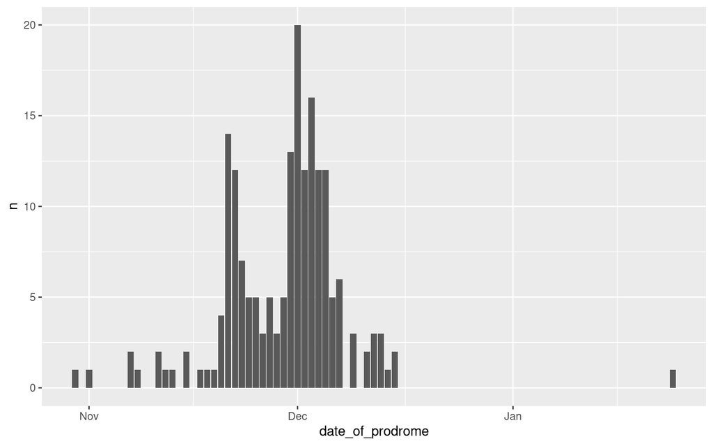

```r
# make basic plot
x_counts %>%
  ggplot(aes(x = date_of_prodrome, y = n)) +
  geom_col()
```

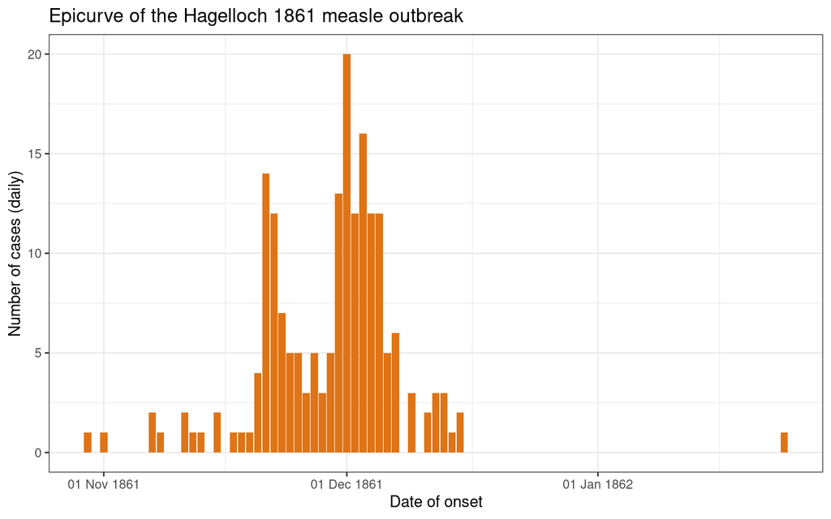

```r
# same plot with some customisation; note that we save the date scale as it
# will be re-used later; see ?strptime for date formats

scale_dates <- scale_x_date(date_labels = "%d %b %Y")

x_counts %>%
  ggplot(aes(x = date_of_prodrome, y = n)) +
  geom_col(fill = "#DF7416") +
  theme_bw() +
  scale_dates +
  labs(title = "Epicurve of the Hagelloch 1861 measle outbreak",
       x = "Date of onset",
       y = "Number of cases (daily)")
```

## Looking at age, gender, and class distributions

Here, we will look at the number of cases by age, gender, and class years. Note that we treat age as a categorical variable, but we could equally treat it as a quantitative variable, in which case we would use other `geom` for data visualisation, such as `geom_histogram` or `geom_density`.

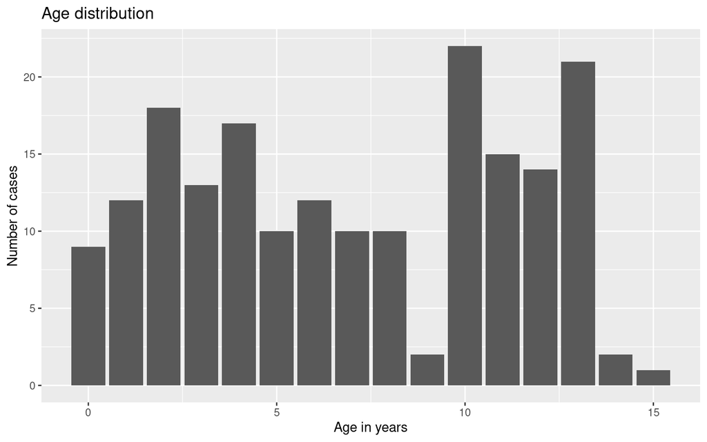

```r
# plotting the age distribution
ggplot(x, aes(x = age)) +
  geom_bar() +
  labs(title = "Age distribution",
       x = "Age in years",
       y = "Number of cases")
```

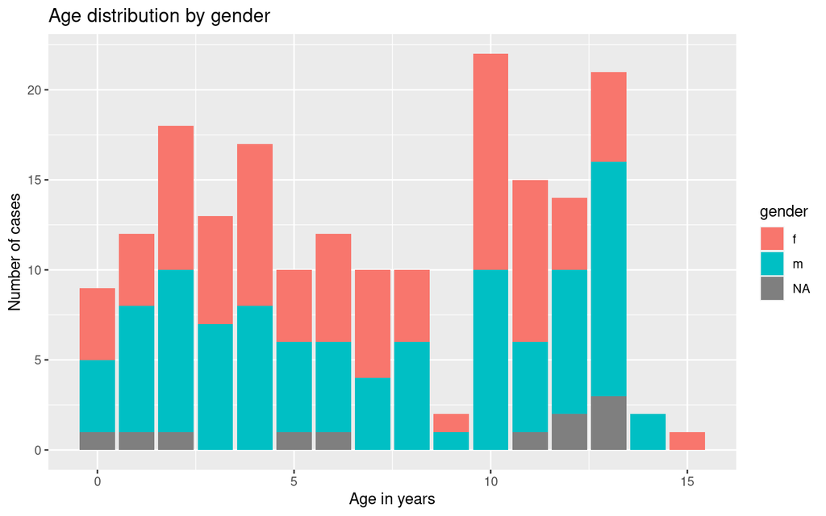

```r
# plotting the age distribution with gender
ggplot(x, aes(x = age)) +
  geom_bar(aes(fill = gender)) +
  labs(title = "Age distribution by gender",
       x = "Age in years",
       y = "Number of cases")
```

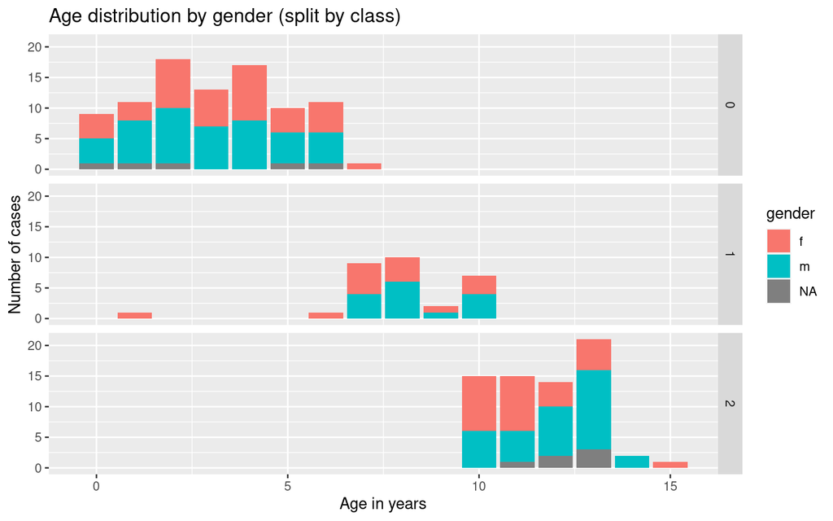

```r
# adding class information
ggplot(x, aes(x = age)) +
  geom_bar(aes(fill = gender)) +
  facet_grid(class ~ .) +
  labs(title = "Age distribution by gender (split by class)",
       x = "Age in years",
       y = "Number of cases")
```

The graph above essentially contains all information we need, but we can customise it slightly to make it clearer, for instance by recoding the `gender` information and accounting for missing data using `fct_recode` from the *forcats* package:

```r
x <- x %>%
  mutate(new_gender = fct_recode(gender,
                                 female = "f",
                                 male = "m"),
         new_gender = fct_explicit_na(new_gender, "missing"))
x %>% count(gender, new_gender) # sanity check
```

```
## # A tibble: 3 × 3
##   gender new_gender     n
##   <fct>  <fct>      <int>
## 1 f      female        83
## 2 m      male          94
## 3 <NA>   missing       11
```

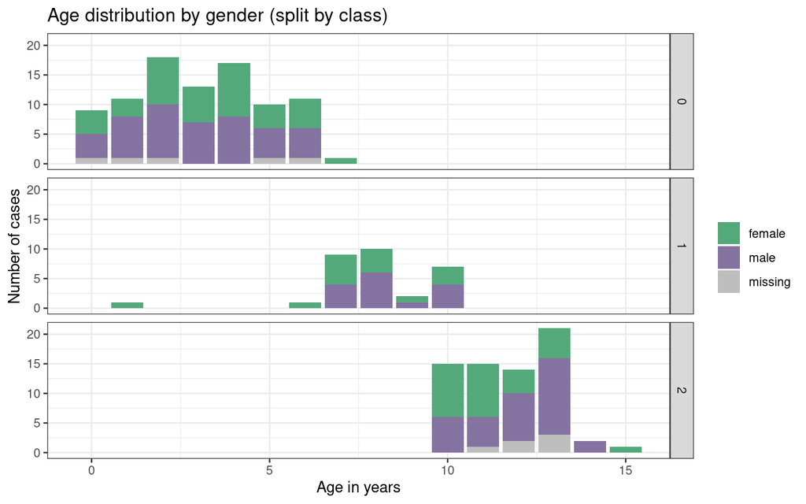

```r
scale_gender <- scale_fill_manual("",
                                  values = c(female = "#54A97B",
                                             male = "#8473A0",
                                             missing = "grey"))
ggplot(x, aes(x = age)) +
  theme_bw() +
  geom_bar(aes(fill = new_gender)) +
  facet_grid(class ~ .) +
  scale_gender +
  labs(title = "Age distribution by gender (split by class)",
       x = "Age in years",
       y = "Number of cases")
```

**Exercise:** use the same approach to create a new variable `new_class`, which will recode *class* so that:

- *0* becomes *preschool*
- *1* becomes *class_1*
- *2* becomes *class_2*

```r
# re-label classes
x <- x %>%
  mutate(new_class = forcats::fct_recode(class,
                                         preschool = "0",
                                         class_1 = "1",
                                         class_2 = "2"))
x %>% count(class, new_class) # sanity check
```

```
## # A tibble: 3 × 3
##   class new_class     n
##   <fct> <fct>     <int>
## 1 0     preschool    90
## 2 1     class_1      30
## 3 2     class_2      68
```

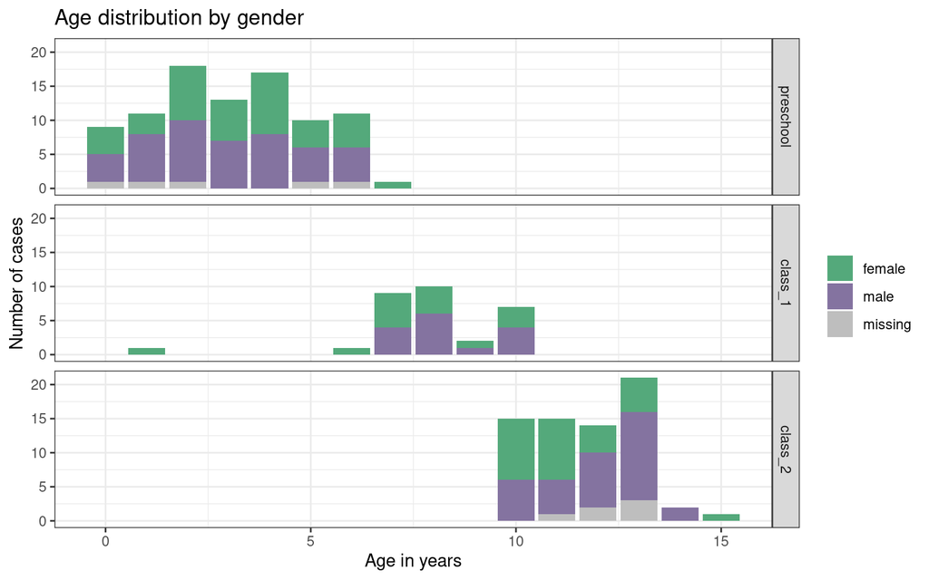

```r
# custom graph
ggplot(x, aes(x = age)) +
  theme_bw() +
  geom_bar(aes(fill = new_gender)) +
  facet_grid(new_class ~ .) +
  scale_fill_manual("",
                    values = c(female = "#54A97B", male = "#8473A0", missing = "grey")) +
  labs(title = "Age distribution by gender",
       x = "Age in years",
       y = "Number of cases")
```

## Building age pyramids

Age-gender distributions are usually displayed as age pyramids. The package [*apyramid*](https://r4epi.github.io/apyramid/), developped as part of the [*R4epis*](https://r4epis.netlify.app/) project, provides a nice implementation for these graphs.

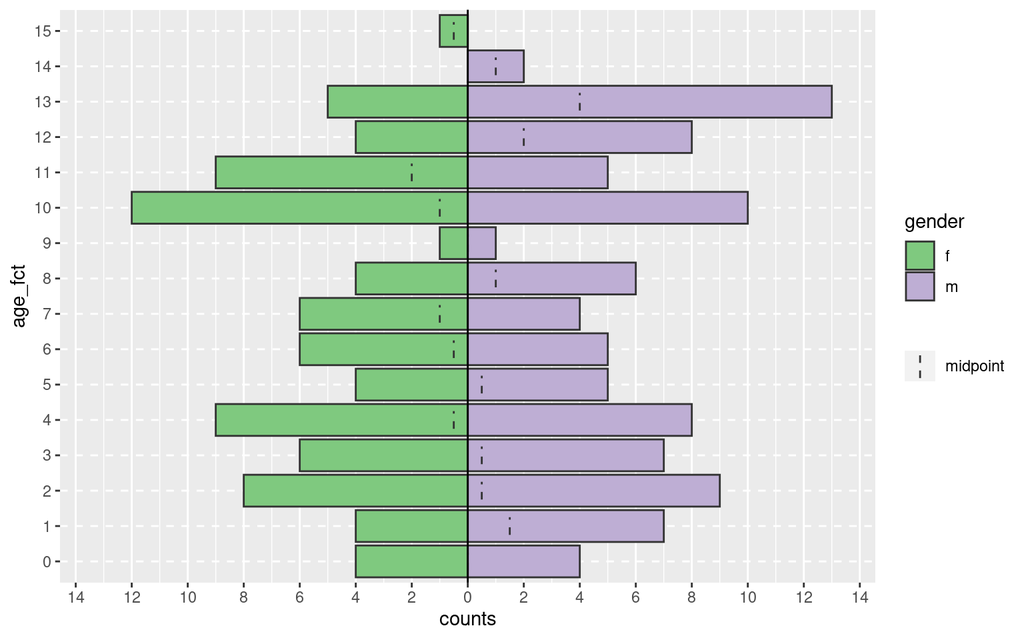

```r
# load apyramid
library(apyramid)

# define age as a factor
x <- x %>%
  mutate(age_fct = factor(age, levels = 0:15))

# make plot
x %>%
  age_pyramid(age_group = age_fct, split_by = gender)
```

```r
# to try: use 'new_gender' instead of 'gender'; why is the graph different?
```

One interesting feature is that additional, non-binary data can be added as colors (see `?age_pyramid` for the argument to use).

**Exercise**: try adding information about the class to the age pyramid; your graph should resemble:

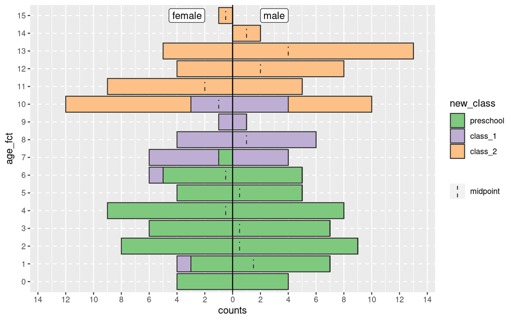

```r
x %>%
  filter(new_gender != "missing") %>%
  droplevels() %>%
  age_pyramid(age_group = age_fct, split_by = new_gender, stack_by = new_class)
```

## Looking at classes dynamics over time

To look at class dynamics over time, we calculate incidence for each day and class. This is made simple by the fact that `count` can use several variables, as illustrated below:

```r
# counts cases by dates and class
x_counts_class <- x %>%
  count(date_of_prodrome, new_class)
x_counts_class
```

```
## # A tibble: 60 × 3
##    date_of_prodrome new_class     n
##    <date>           <fct>     <int>
##  1 1861-10-30       class_2       1
##  2 1861-11-01       preschool     1
##  3 1861-11-07       preschool     1
##  4 1861-11-07       class_1       1
##  5 1861-11-08       preschool     1
##  6 1861-11-11       preschool     1
##  7 1861-11-11       class_1       1
##  8 1861-11-12       preschool     1
##  9 1861-11-13       class_2       1
## 10 1861-11-15       preschool     1
## # … with 50 more rows
```

**Exercise**: using these data, and building on graphs you made so far, plot an epidemic curve showing cases by class over time; your graph may resemble the following:

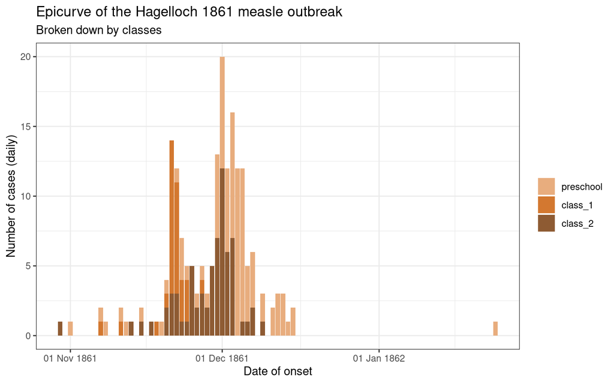

```r
# custom color scale
scale_class <- scale_fill_manual("",
                                 values = c(preschool = "#E8AD7E",
                                            class_1 = "#D37830",
                                            class_2 = "#8E5B33"))
# make plot
x_counts_class %>%
  ggplot(aes(x = date_of_prodrome, y = n)) +
  theme_bw() +
  geom_col(aes(fill = new_class)) +
  scale_class +
  scale_dates +
  labs(title = "Epicurve of the Hagelloch 1861 measle outbreak",
       subtitle = "Broken down by classes",
       x = "Date of onset",
       y = "Number of cases (daily)")
```

**Explanation:**  
The epidemic curve suggests that classes might have impacted the spread of the disease: we first see a flare-up in *class 1*, then in *class 2* and the *preschool class*. However, this is far from conclusive at this stage: transmission chains data would be needed to further investigate how the class structure impacted transmission.

# Outbreak 2: Ebola virus disease in Sierra Leone, 2014

This dataset represents a subset of the large Ebola outbreak which took place in West Africa in 2013-2016. The dataset we analyse is a linelist of cases from Sierra Leone published by Fang et al. (2016), which covers the period 2014-05-18 to 2015-09-13, and includes both confirmed and suspected cases.

## Importing the data

For this example, we will import data from an Excel spreadsheet using the package `rio` and its handy function `import`. This function automatically detects the type of file from its extension and uses the appropriate method to import the data into **R**.

To read the data in, follow these steps:

1. in your current R project, create a folder called `data/` (all lower case)
2. download the data (file: `ebola_sierraleone_2014.xlsx`) from the moodle, and save it in the `data/` folder

**Tip**

This dataset is also available in the *outbreaks* package under the same name.

```r
# find path to data
path_to_file <- here::here("data", "ebola_sierraleone_2014.xlsx")
path_to_file
```

```
## [1] "/home/thibaut/dev/teaching/soar21/day1/practicals/data/ebola_sierraleone_2014.xlsx"
```

```r
# read file in and convert to tibble
x <- path_to_file %>%
  rio::import() %>%
  tibble()

# fix dates (we don't have date-time)
x <- x %>%
  mutate(date_of_onset = as.Date(date_of_onset),
         date_of_sample = as.Date(date_of_sample))

# note: fast alternative to fix all dates in one go is:
# x %>% mutate(across(contains("date"), as.Date))
```

**Exercise**: using `glimpse`, `View`, and `summary`, have a look at the data’s content. You can find documentation on the variable’s content using `?ebola_sierraleone_2014` (requires loading *outbreaks*).

```r
glimpse(x)
```

```
## Rows: 11,903
## Columns: 8
## $ id             <dbl> 1, 2, 3, 4, 5, 6, 7, 8, 9, 10, 11, 12, 13, 14, 15, 16, …
## $ age            <dbl> 20, 42, 45, 15, 19, 55, 50, 8, 54, 57, 50, 27, 38, 29, …
## $ sex            <chr> "F", "F", "F", "F", "F", "F", "F", "F", "F", "F", "F", …
## $ status         <chr> "confirmed", "confirmed", "confirmed", "confirmed", "co…
## $ date_of_onset  <date> 2014-05-18, 2014-05-20, 2014-05-20, 2014-05-21, 2014-0…
## $ date_of_sample <date> 2014-05-23, 2014-05-25, 2014-05-25, 2014-05-26, 2014-0…
## $ district       <chr> "Kailahun", "Kailahun", "Kailahun", "Kailahun", "Kailah…
## $ chiefdom       <chr> "Kissi Teng", "Kissi Teng", "Kissi Tonge", "Kissi Teng"…
```

```r
summary(x)
```

```
##        id             age           sex               status
##  Min.   :    1   Min.   : 0.0   Length:11903       Length:11903
##  1st Qu.: 2976   1st Qu.:16.0   Class :character   Class :character
##  Median : 5952   Median :28.0   Mode  :character   Mode  :character
##  Mean   : 5952   Mean   :30.3
##  3rd Qu.: 8928   3rd Qu.:42.0
##  Max.   :11903   Max.   :92.0
##                  NA's   :956
##  date_of_onset        date_of_sample         district
##  Min.   :2014-05-18   Min.   :2014-05-23   Length:11903
##  1st Qu.:2014-10-05   1st Qu.:2014-10-12   Class :character
##  Median :2014-11-18   Median :2014-11-24   Mode  :character
##  Mean   :2014-12-04   Mean   :2014-12-10
##  3rd Qu.:2015-01-11   3rd Qu.:2015-01-16
##  Max.   :2015-09-12   Max.   :2015-09-13
##
##    chiefdom
##  Length:11903
##  Class :character
##  Mode  :character
##
##
##
##
```

## Making a basic epidemic curve

We use the same approach as in the previous example to derive an epidemic curve by date of symptom onset:

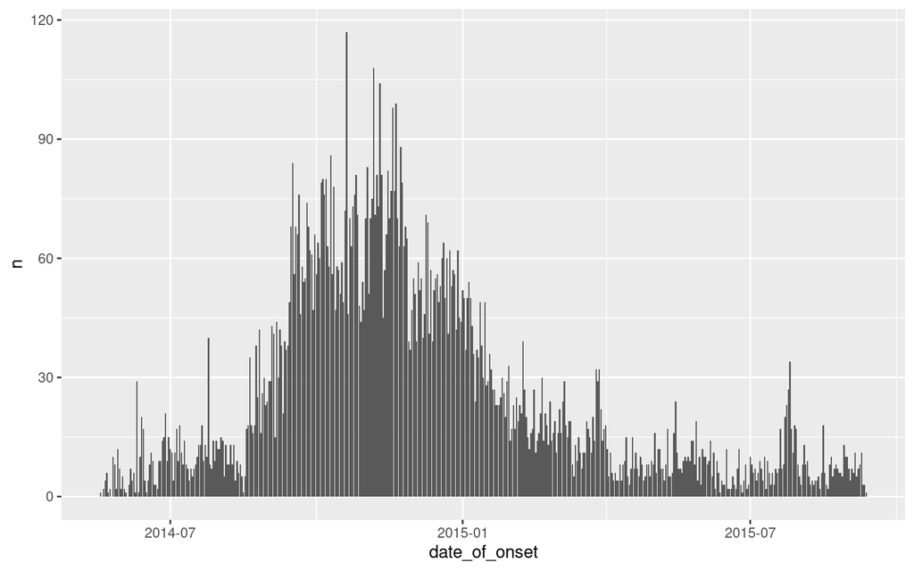

```r
# calculate case incidence
x_counts <- x %>%
  count(date_of_onset)

# basic plot
x_counts %>%
  ggplot(aes(x = date_of_onset, y = n)) +
  geom_col()
```

**Exercise**: re-use code from the previous example to make a second, cleaner graph, which would resemble the one below.

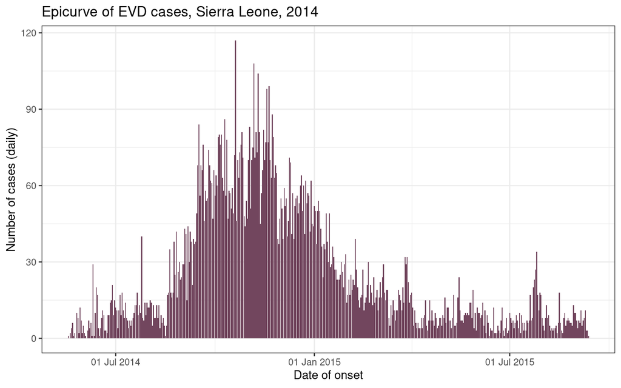

```r
x_counts %>%
  ggplot(aes(x = date_of_onset, y = n)) +
  geom_col(fill = "#72465E") +
  theme_bw() +
  scale_dates +
  labs(title = "Epicurve of EVD cases, Sierra Leone, 2014",
       x = "Date of onset",
       y = "Number of cases (daily)")
```

## Breaking cases by district

In the following, we provide a breakdown of cases by district (the coarser geographic unit), by providing:

1. case counts by district, and case status
2. plotting the resulting counts
3. calculating the percentage of the confirmed/suspected cases coming from each district

```r
# 1. derive case counts by status and district
# (note that we don't save the result)
x %>% count(status, district)
```

```
## # A tibble: 28 × 3
##    status    district      n
##    <chr>     <chr>     <int>
##  1 confirmed Bo          315
##  2 confirmed Bombali    1049
##  3 confirmed Bonthe        6
##  4 confirmed Kailahun    524
##  5 confirmed Kambia      241
##  6 confirmed Kenema      497
##  7 confirmed Koinadugu   111
##  8 confirmed Kono        263
##  9 confirmed Moyamba     210
## 10 confirmed Port Loko  1202
## # … with 18 more rows
```

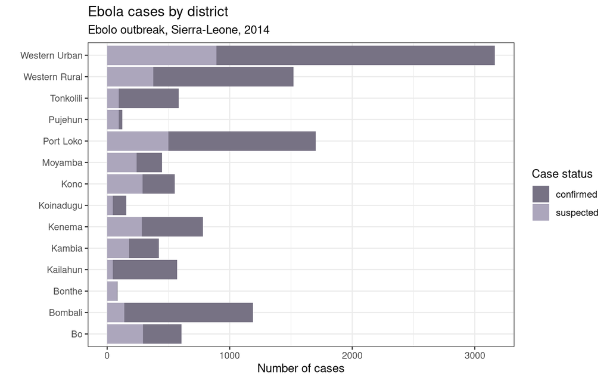

```r
# 2. make a plot
x %>%
  count(status, district) %>%
  ggplot(aes(y = district, x = n)) +
  theme_bw() +
  geom_col(aes(fill = status)) +
  scale_fill_manual("Case status",
                    values = c(confirmed = "#777284",
                               suspected = "#ACA6BC")) +
  labs(title = "Ebola cases by district",
       subtitle = "Ebolo outbreak, Sierra-Leone, 2014 ",
       x = "Number of cases",
       y = "")
```

```r
# 3. % of total confirmed cases by district
x %>%
  count(status, district) %>%
  spread(status, n) %>%
  mutate(perc_confirmed = 100 * confirmed / sum(confirmed),
         perc_suspected = 100 * suspected / sum(suspected))
```

```
## # A tibble: 14 × 5
##    district      confirmed suspected perc_confirmed perc_suspected
##    <chr>             <int>     <int>          <dbl>          <dbl>
##  1 Bo                  315       291         3.77             8.21
##  2 Bombali            1049       141        12.6              3.98
##  3 Bonthe                6        78         0.0718           2.20
##  4 Kailahun            524        46         6.27             1.30
##  5 Kambia              241       180         2.88             5.08
##  6 Kenema              497       283         5.95             7.98
##  7 Koinadugu           111        46         1.33             1.30
##  8 Kono                263       288         3.15             8.12
##  9 Moyamba             210       239         2.51             6.74
## 10 Port Loko          1202       499        14.4             14.1
## 11 Pujehun              31        93         0.371            2.62
## 12 Tonkolili           489        94         5.85             2.65
## 13 Western Rural      1146       376        13.7             10.6
## 14 Western Urban      2274       891        27.2             25.1
```

We can also generate separate epidemic curves by districts. As there are slightly too many districts for useful use of colors, we use `facet_wrap` to generate separate plots.

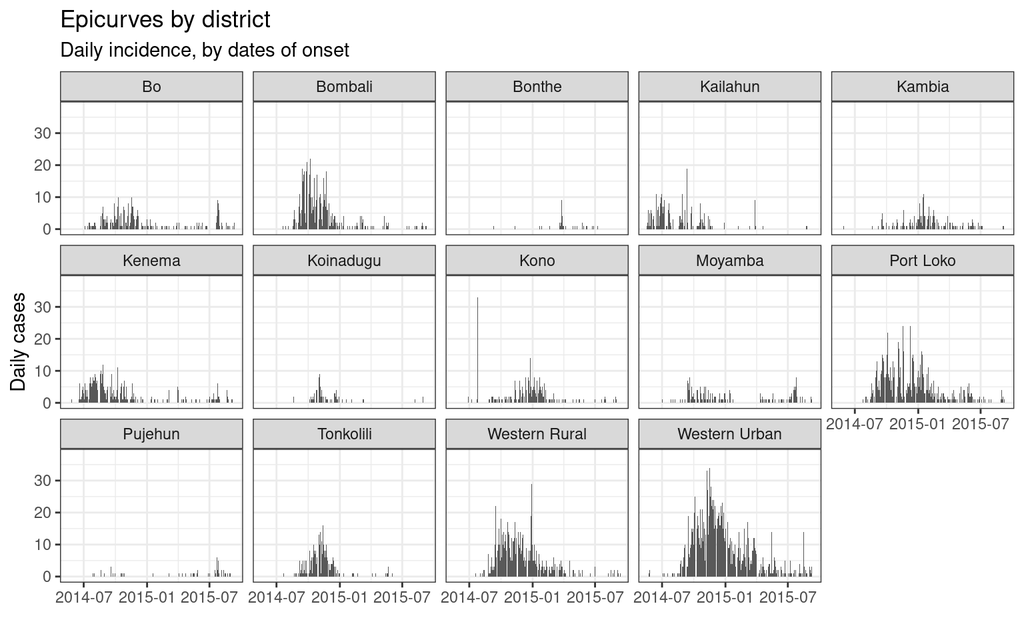

```r
# counts by district
x_counts_districts <- x %>%
  group_by(date_of_onset, district) %>%
  count()

# plot
x_counts_districts %>%
  ggplot(aes(x = date_of_onset, y = n)) +
  theme_bw() +
  geom_col() +
  facet_wrap(~ district, nrow = 3) +
  theme(strip.text.y = element_text(angle= 0)) +
  labs(title = "Epicurves by district",
       subtitle = "Daily incidence, by dates of onset",
       x = "",
       y = "Daily cases")
```

## Comparing cases across disticts and chiefdoms

**Exercise**: examine the code and figures below, and interpret the results; what do these figures show? what does it potentially say about surveillance in different districts / chiefdoms?

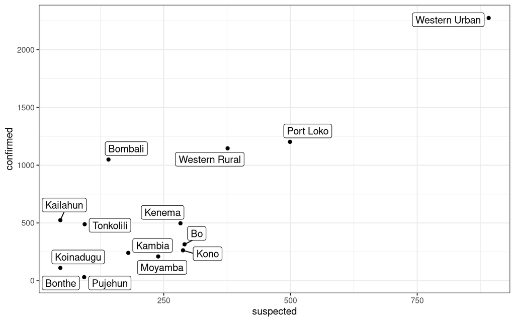

```r
x_status_district <- x %>%
  count(district, status) %>%
  spread(status, n, fill = 0)


x_status_district %>%
  ggplot(aes(x = suspected, y = confirmed)) +
  geom_point() +
  geom_label_repel(aes(label = district)) +
  theme_bw()
```

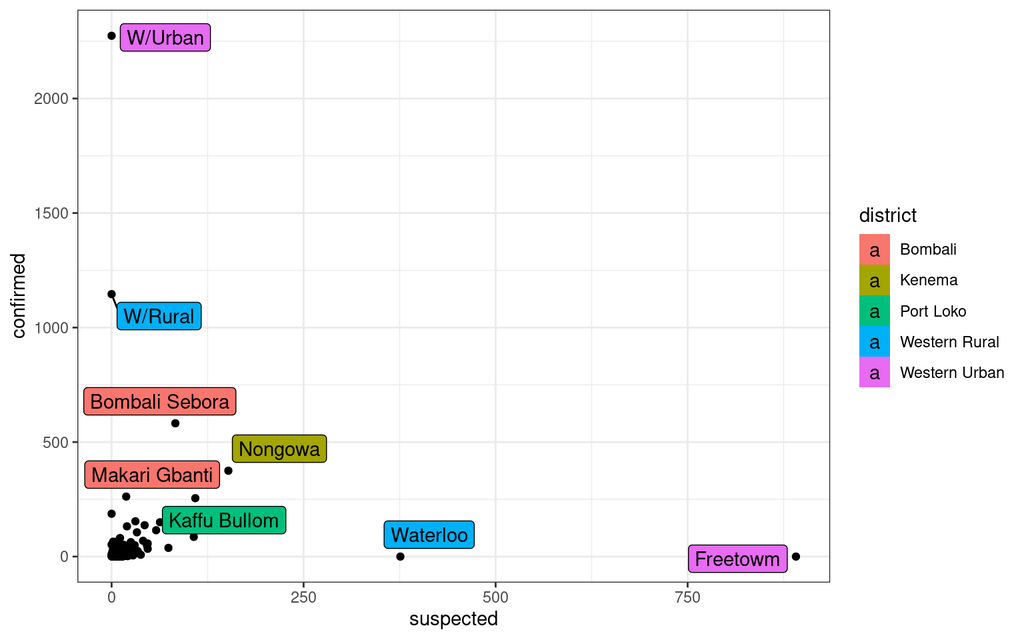

```r
x_status_chiefdom <- x %>%
  count(district, chiefdom, status) %>%
  spread(status, n, fill = 0)

x_status_chiefdom %>%
  ggplot(aes(x = suspected, y = confirmed)) +
  geom_point() +
  geom_label_repel(
    data = filter(
      x_status_chiefdom,
      suspected > 250 | confirmed > 250),
    aes(label = chiefdom, fill = district)) +
  theme_bw()
```

**Explanation:**  
We would normally expect numbers of confirmed and suspected cases to be positively correlated, and this is what we actually observe at a district level. When looking at this relationship at a chiefdom level, however, we find that there are a few outliers not following this relationship at all: some chiefdoms have a lot more confirmed than suspected cases, or the other way around. This could reflect different things: different epicase definition (which would need harmonising), or different testing capacity (with less ‘confirmed’ cases where testing is limited), or poorer surveillance in locations with many suspected cases (e.g. if these are akeen to community deaths).

## Age and gender distributions

As previously, we use the package [*apyramid*](https://r4epi.github.io/apyramid/) to visualise age-gender demographics amongst confirmed and suspected cases. However, rather than using actual ages as we did before, we will now define age classes. Several approaches can be used, depending on whether we want specific age classes, or merely a limited number of bins to summarise the data with. Here, we opt for the latter, using a small *ad-hoc* function `autocut` which will partition data into a given number of equally-sized bins:

```r
# We define a function to break ages into bins
## 'x' is a vector of number (ages)
## 'n' is an ideal number of bins seeked; defaults to 5
autocut <- function(x, n = 5) {
  cut(x, breaks = pretty(x, n = n), right = TRUE, include.lowest = TRUE)
}

# Example of how it works
tibble(age = 0:11) %>%
  mutate(age_group = autocut(age))
```

```
## # A tibble: 12 × 2
##      age age_group
##    <int> <fct>
##  1     0 [0,2]
##  2     1 [0,2]
##  3     2 [0,2]
##  4     3 (2,4]
##  5     4 (2,4]
##  6     5 (4,6]
##  7     6 (4,6]
##  8     7 (6,8]
##  9     8 (6,8]
## 10     9 (8,10]
## 11    10 (8,10]
## 12    11 (10,12]
```

**Exercise**: using the example provided above, as well as previous code for recoding factors:

- add to `x` a new variable `new_sex` recoding ‘M’ to ‘male’ and ‘F’ to ‘female’
- add to `x` a new variable `age_group` creating age groups with 10 categories

```r
x <- x %>%
  mutate(new_sex = forcats::fct_recode(sex,
                                       female = "F",
                                       male = "M"),
         age_group = autocut(age, 10))
```

Then, you can create the age pyramid using:

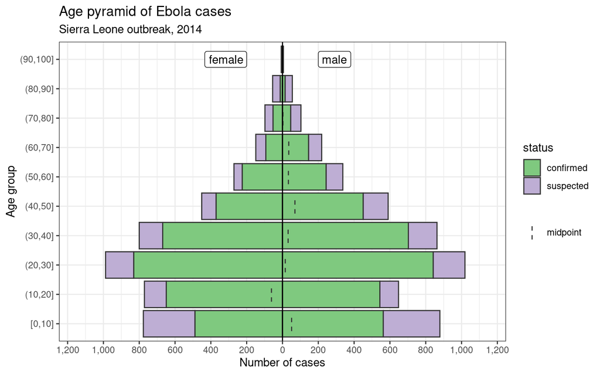

```r
x %>%
  age_pyramid(split_by = "new_sex", stack_by = "status") +
  theme_bw() +
  labs(title = "Age pyramid of Ebola cases",
       subtitle = "Sierra Leone outbreak, 2014",
       y = "Number of cases",
       x = "Age group")
```

What can you say of this age-gender distribution?

## Gender distributions across districts

In this part, we will count cases by districts and gender, and try to assess whether some significant differences in sex ratio exist across districts.

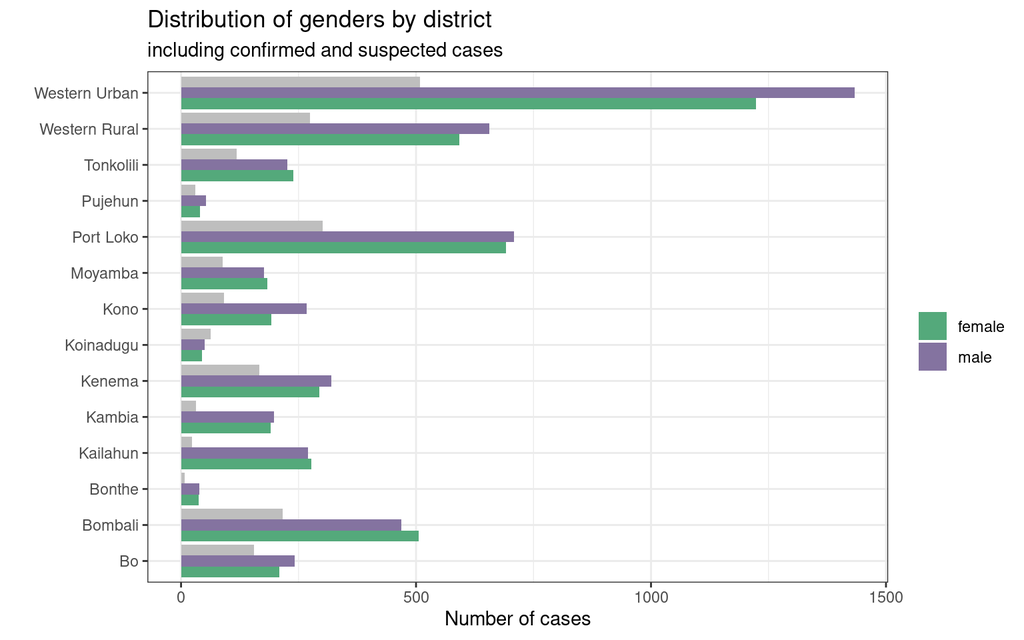

```r
# Define a custom color scale; note how we can specify the value for missing
# data when they are not coded as their own category
scale_sex <- scale_fill_manual("",
                               values = c(female = "#54A97B",
                                          male = "#8473A0"),
                               na.value = "grey")

# Derive counts and make plot on the fly
x %>%
  count(new_sex, district) %>%
  ggplot(aes(x = n, y = district)) +
  theme_bw() +
  geom_col(aes(fill = new_sex), position = "dodge") +
  scale_sex +
    labs(title = "Distribution of genders by district",
         subtitle = "including confirmed and suspected cases",
         x = "Number of cases",
         y = "")
```

What does this graph suggest in terms of gender distribution across districts? Do you find evidence for a specific bias?

To investigate this further, we shall compare the proportions of males across districts. To this end, we will need to use a function which will compute the confidence intervals for each proportion. This is achieved by the *ad-hoc* function `prop_ci`, defined below. Note that you do not need to understand the underlying code at this stage. Simply copy-paste the code and the function will work.

```r
#' This function uses `binom.test` to derive estimates of the 95% CI for
#' proportions.
#'
#' @param k number of successes
#'
#' @param n number of trials
#'
#' @param conf confidence level, defaults to 0.95
#'
#' @param result a `character` vector indicating which bounds of the confidence
#'   interval to return: can be `"lower"`, or `"upper"`, or `"both"`
#'
#' @author Thibaut Jombart
#'

prop_ci <- function(k, n,
                    result = c("both", "lower", "upper"),
                    conf = 0.95) {
  if(n == 0){
    out = c(0,1)
  } else {
    out <- binom.test(k, n, conf.level = conf)$conf.int
    result <- match.arg(result)
  }
  if (result == "both") {
    result <- c("lower", "upper")
  }
  names(out) <- c("lower", "upper")
  out <- out[result]

  out
}

prop_ci <- Vectorize(prop_ci)


# Some examples
prop_ci(10, 30)
```

```
##            [,1]
## lower 0.1728742
## upper 0.5281200
```

```r
prop_ci(100, 300)
```

```
##            [,1]
## lower 0.2802048
## upper 0.3897924
```

```r
prop_ci(10, 30, "lower")
```

```
##     lower
## 0.1728742
```

```r
prop_ci(10, 30, "upper")
```

```
##   upper
## 0.52812
```

In the following, we:

- derive counts by gender and district
- calculate the proportion of males in each district
- derive the associated confidence intervals

```r
gender_stats <- x %>%
  filter(!is.na(new_sex)) %>%
  count(district, new_sex) %>%
  spread(new_sex, n) %>%
  mutate(total = female + male,
         p_male = male / total,
         p_low = prop_ci(male, total, "lower"),
         p_high = prop_ci(male, total, "upper"))
gender_stats
```

```
## # A tibble: 14 × 7
##    district      female  male total p_male p_low p_high
##    <chr>          <int> <int> <int>  <dbl> <dbl>  <dbl>
##  1 Bo               209   242   451  0.537 0.489  0.583
##  2 Bombali          505   469   974  0.482 0.450  0.513
##  3 Bonthe            37    39    76  0.513 0.396  0.630
##  4 Kailahun         277   270   547  0.494 0.451  0.536
##  5 Kambia           191   198   389  0.509 0.458  0.560
##  6 Kenema           294   320   614  0.521 0.481  0.561
##  7 Koinadugu         44    50    94  0.532 0.426  0.636
##  8 Kono             192   268   460  0.583 0.536  0.628
##  9 Moyamba          183   177   360  0.492 0.439  0.545
## 10 Port Loko        692   708  1400  0.506 0.479  0.532
## 11 Pujehun           40    53    93  0.570 0.463  0.672
## 12 Tonkolili        239   226   465  0.486 0.440  0.532
## 13 Western Rural    592   656  1248  0.526 0.498  0.554
## 14 Western Urban   1224  1433  2657  0.539 0.520  0.558
```

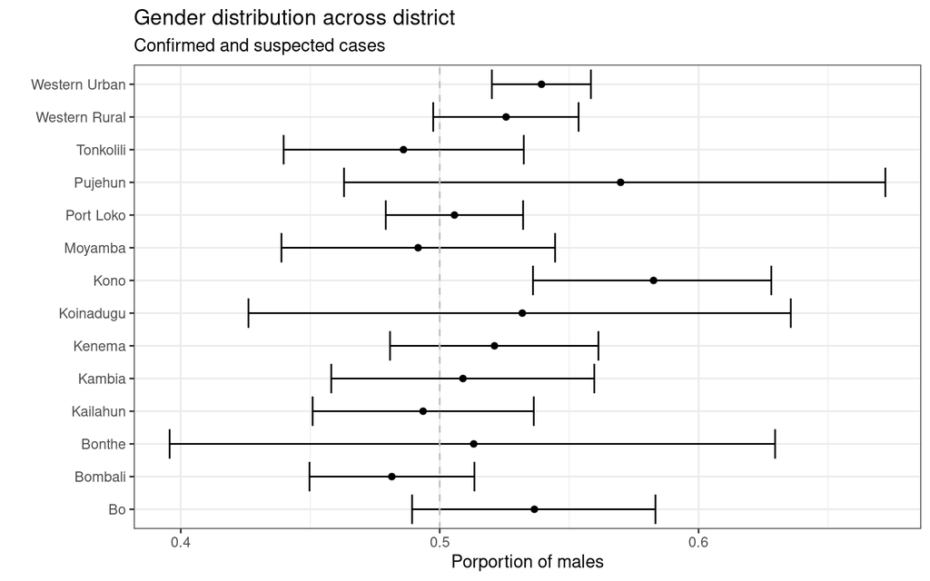

```r
gender_stats %>%
  ggplot(aes(y = district, x = p_male)) +
  geom_point() +
  geom_errorbar(aes(xmin = p_low, xmax = p_high)) +
  theme_bw() +
  geom_vline(xintercept = 0.5, linetype = 2, color = "grey") +
  labs(title = "Gender distribution across district",
       subtitle = "Confirmed and suspected cases",
       x = "Porportion of males", y = "")
```

How would you interpret these results? If you had observed this during the response, what follow-up action would you have recommended?

**Explanation:**  
When looking at raw numbers, it is not clear if there is a bias towards a particular gender in some locations. However, the proportion of males and its confidence interval shows that in two districts (*Western Urban* and *Kono*), the proportion of males amongst cases is significantly higher than in a balanced sex ratio. This could be indicative of a genuine difference, but also reflect a selection bias in testing or surveillance, which should be investigated.

# References

Fang, Li-Qun, Yang Yang, Jia-Fu Jiang, Hong-Wu Yao, David Kargbo, Xin-Lou Li, Bao-Gui Jiang, et al. 2016. “Transmission Dynamics of Ebola Virus Disease and Intervention Effectiveness in Sierra Leone.” *Proceedings of the National Academy of Sciences*.

Neal, Peter J, and Gareth O Roberts. 2004. “Statistical Inference and Model Selection for the 1861 Hagelloch Measles Epidemic.” *Biostatistics* 5 (2): 249–61.

Oesterle, Heike. 1993. “Statistische Reanalyse Einer Masernepidemie 1861 in Hagelloch.” PhD thesis, Uitgever niet vastgesteld.